# Moth Records

## Buttoned snout

In total, I have caught 1 individuals of Buttoned snout, in 1 traps, between 2021 and 2021.

## Cabbage

In total, I have caught 15 individuals of Cabbage, in 11 traps, between 2021 and 2025.

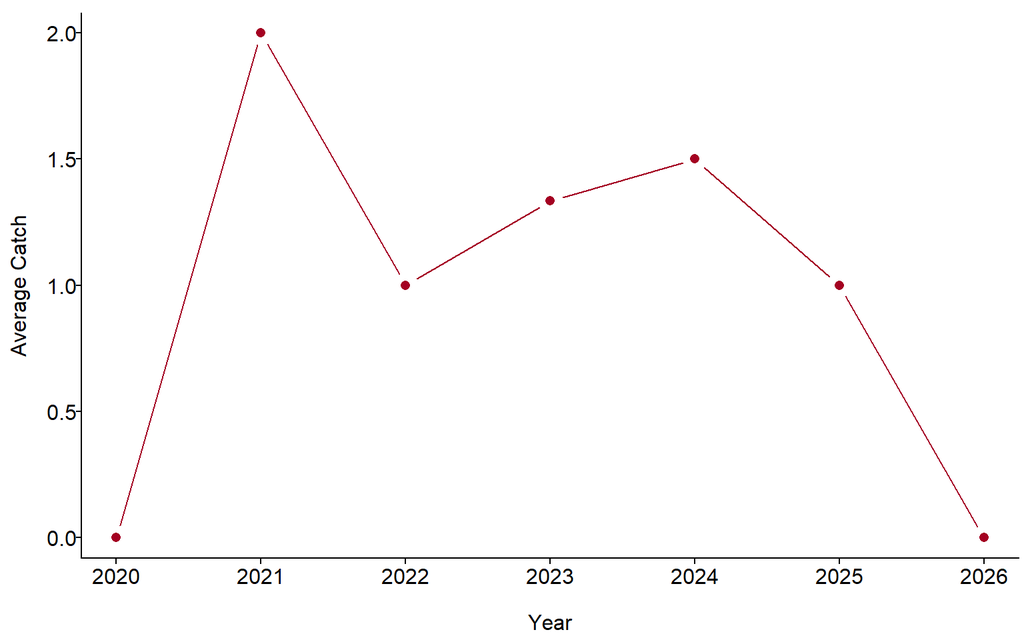

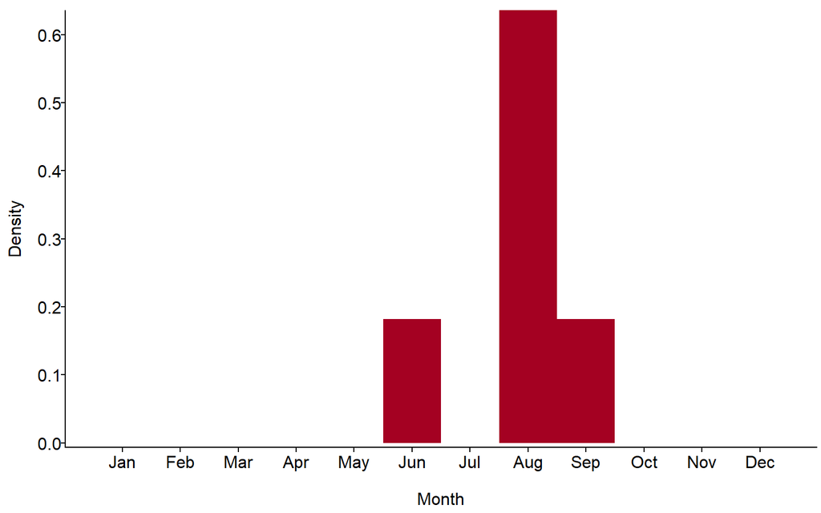

## Campion

In total, I have caught 1 individuals of Campion, in 1 traps, between 2021 and 2021.

## Canary-shouldered thorn

In total, I have caught 1 individuals of Canary-shouldered thorn, in 1 traps, between 2022 and 2022.

## Centre-barred sallow

In total, I have caught 63 individuals of Centre-barred sallow, in 18 traps, between 2020 and 2026.

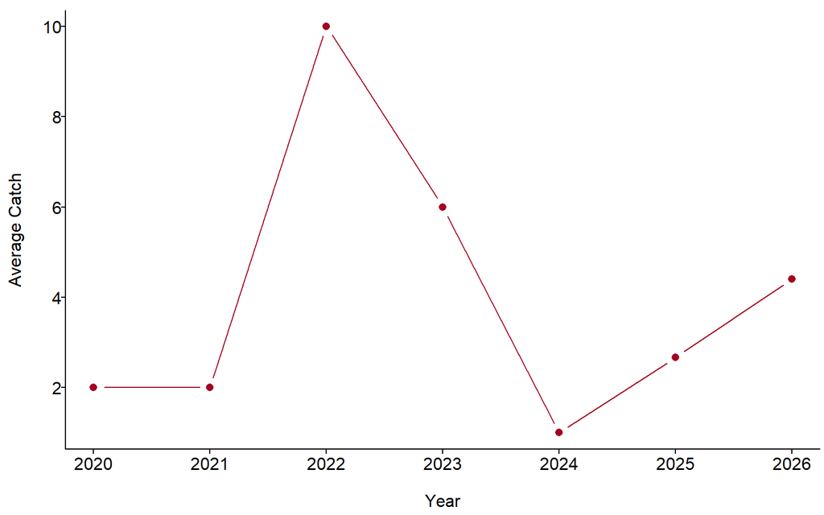

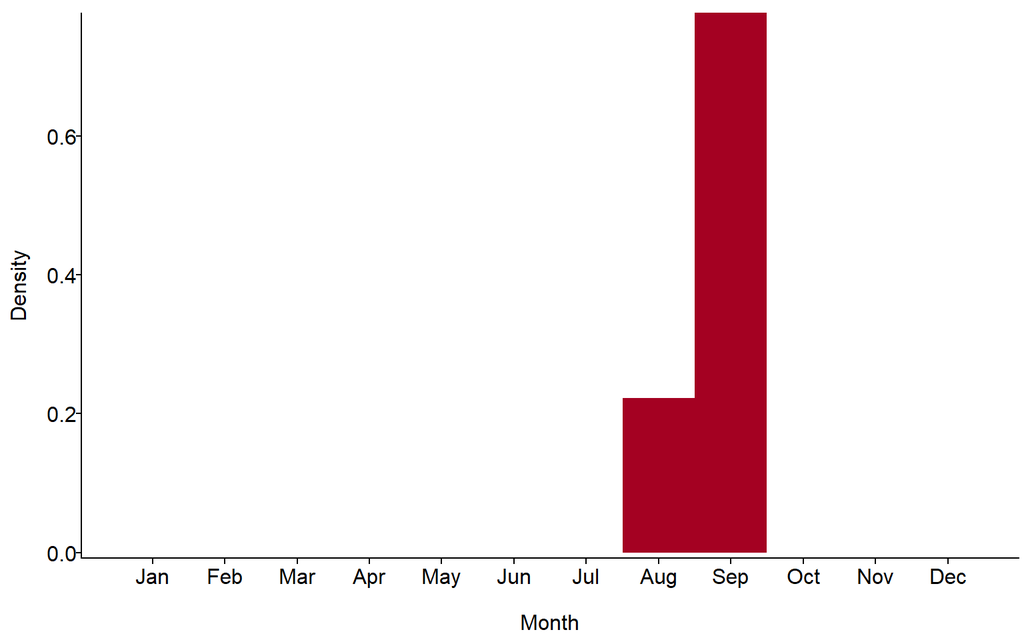

## Chestnut

In total, I have caught 5 individuals of Chestnut, in 5 traps, between 2020 and 2025.

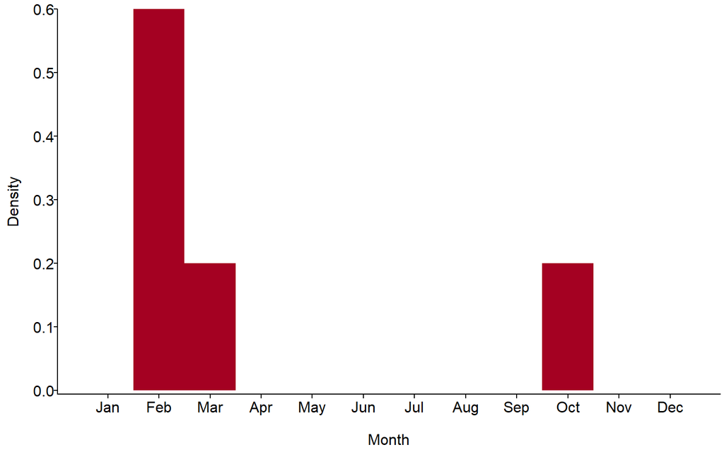

## Chinese character

In total, I have caught 21 individuals of Chinese character, in 18 traps, between 2020 and 2026.

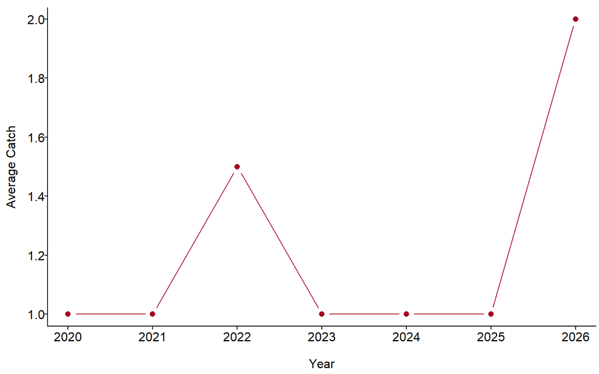

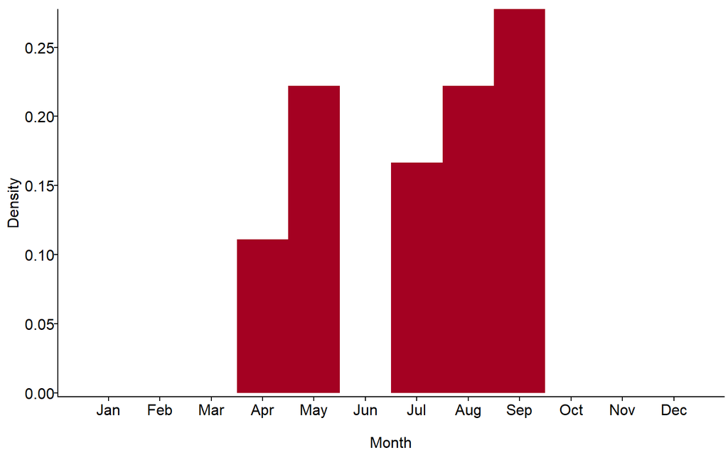

## Chocolate-tip

In total, I have caught 5 individuals of Chocolate-tip, in 3 traps, between 2022 and 2026.

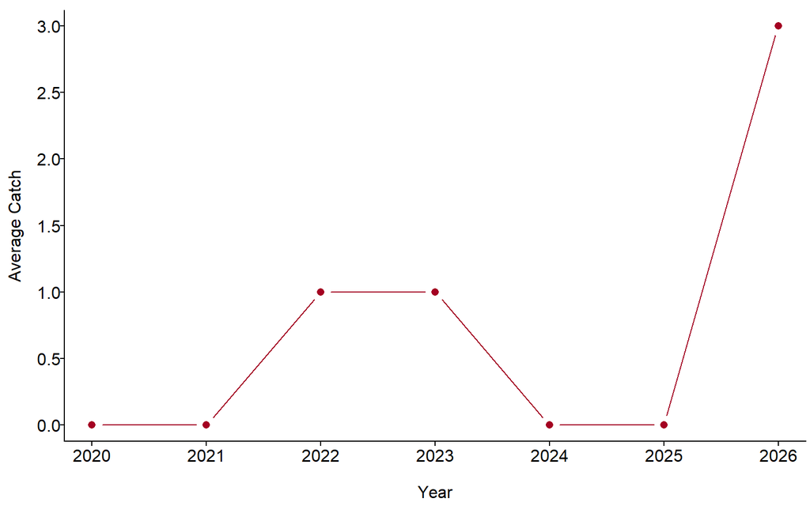

## Cinnabar

In total, I have caught 16 individuals of Cinnabar, in 14 traps, between 2021 and 2026.

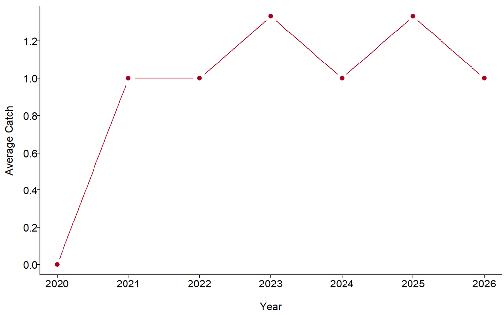

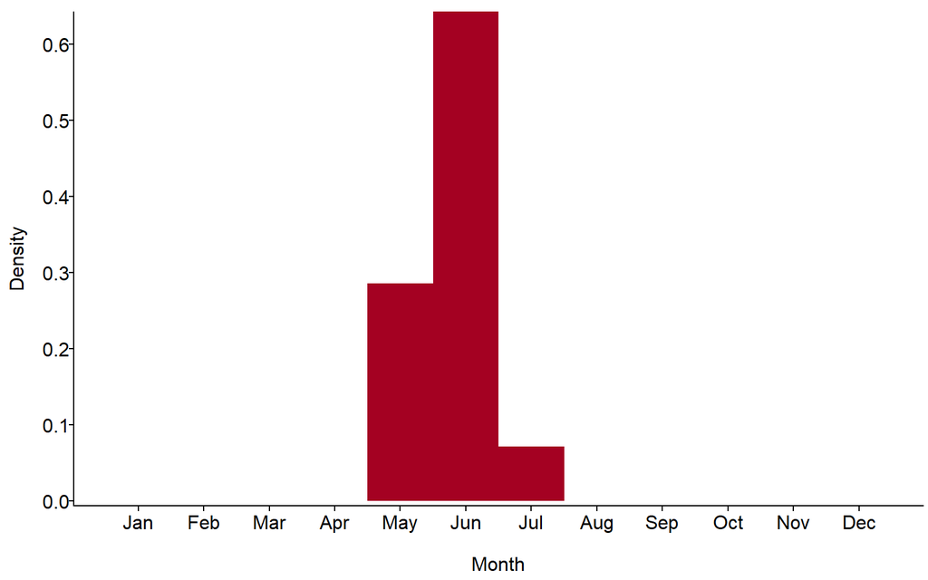

## Clancy’s rustic

In total, I have caught 11 individuals of Clancy’s rustic, in 9 traps, between 2023 and 2026.

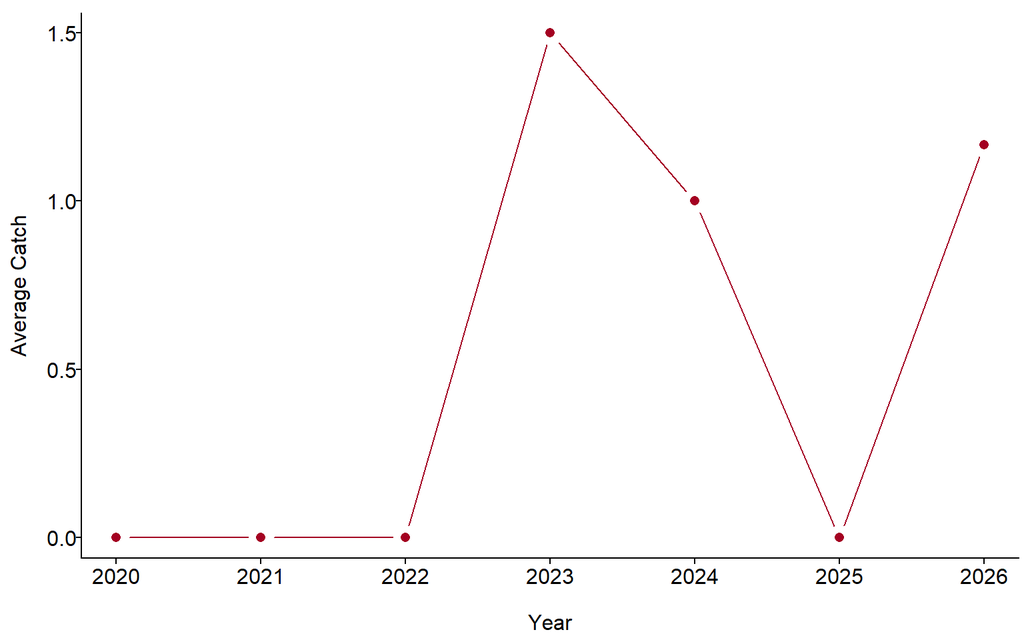

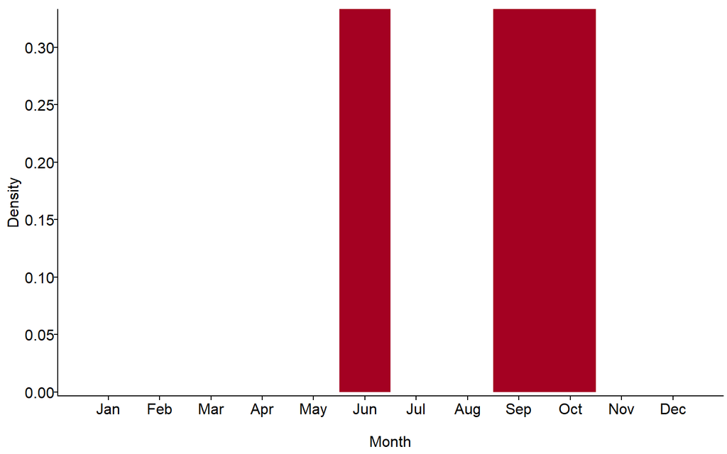

## Clay

In total, I have caught 12 individuals of Clay, in 8 traps, between 2020 and 2025.

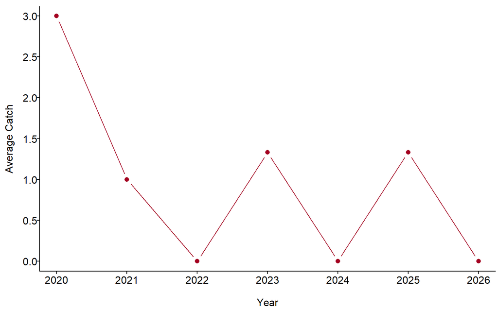

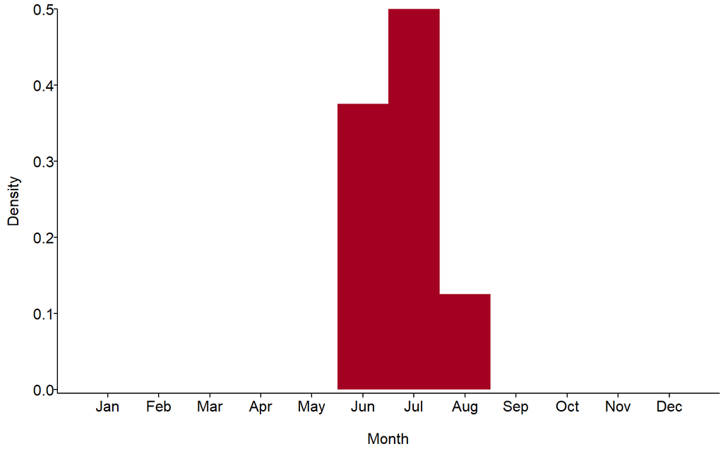

## Clifden non-pareil

In total, I have caught 1 individuals of Clifden non-pareil, in 1 traps, between 2022 and 2022.

## Cloaked minor

In total, I have caught 24 individuals of Cloaked minor, in 8 traps, between 2020 and 2026.

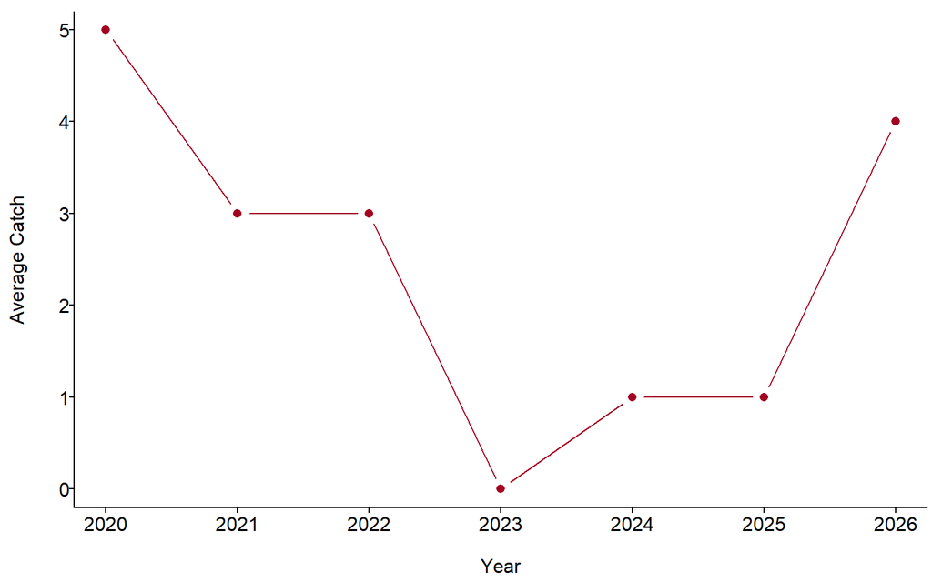

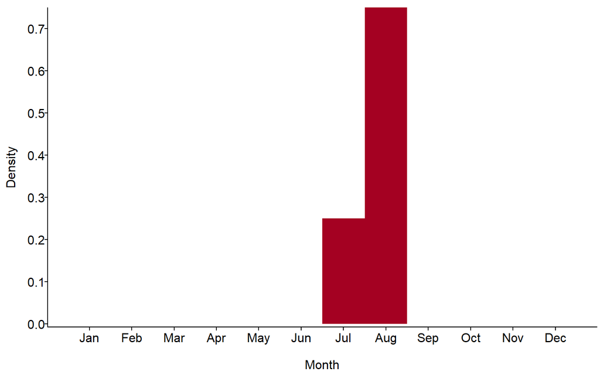

## Clouded border

In total, I have caught 1 individuals of Clouded border, in 1 traps, between 2022 and 2022.

## Clouded drab

In total, I have caught 57 individuals of Clouded drab, in 30 traps, between 2021 and 2026.

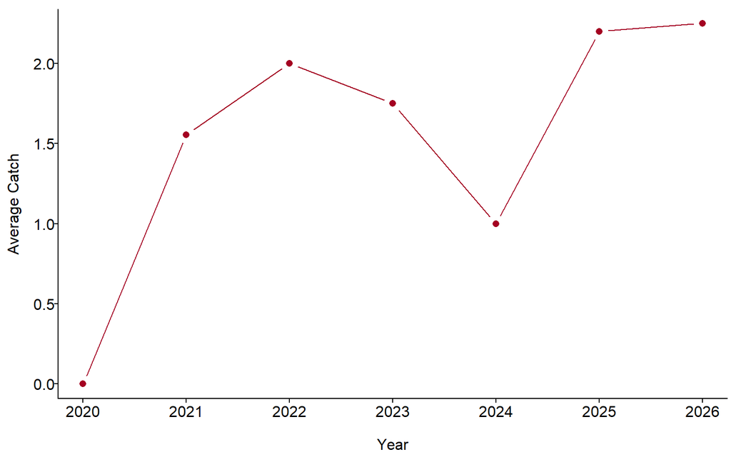

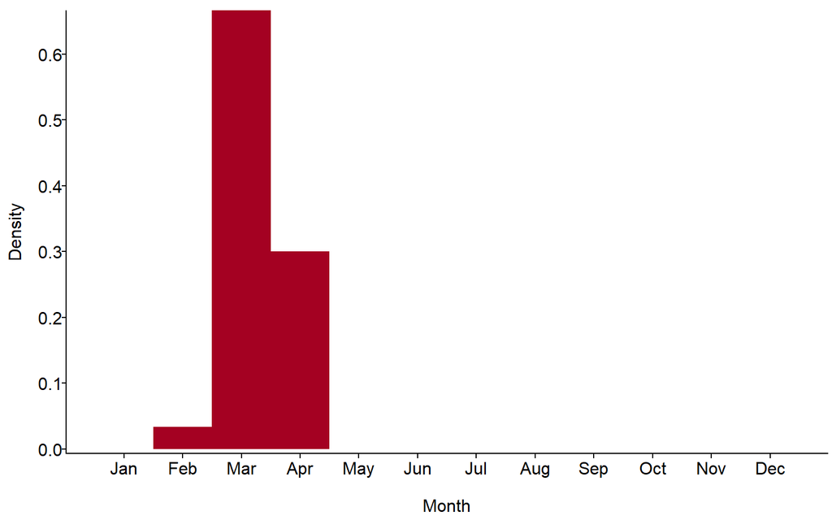

## Common carpet

In total, I have caught 20 individuals of Common carpet, in 16 traps, between 2020 and 2026.

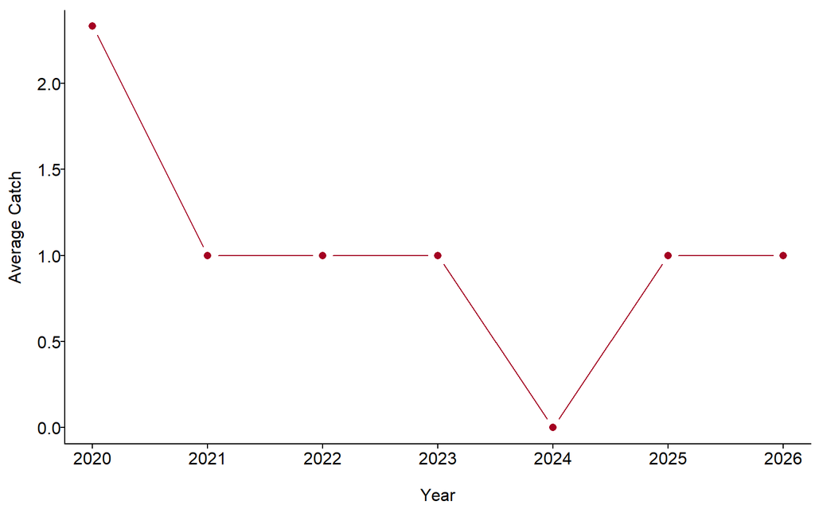

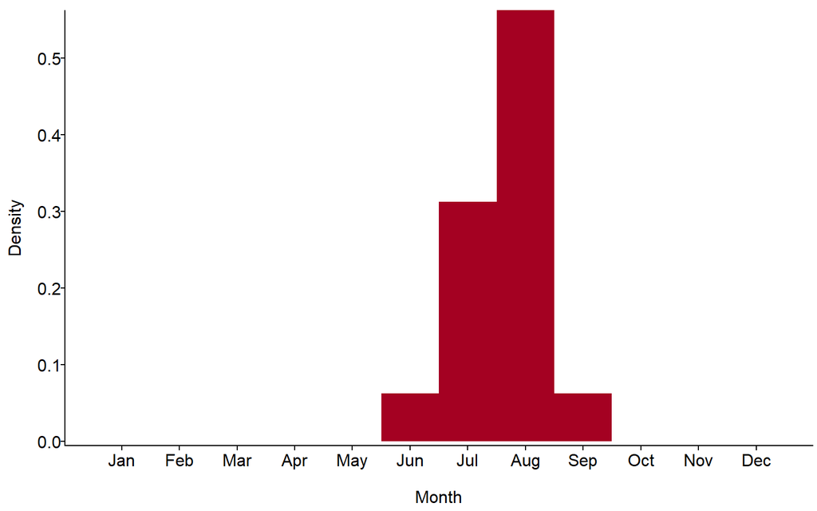

## Common emerald

In total, I have caught 1 individuals of Common emerald, in 1 traps, between 2022 and 2022.

## Common footman

In total, I have caught 821 individuals of Common footman, in 68 traps, between 2020 and 2026.

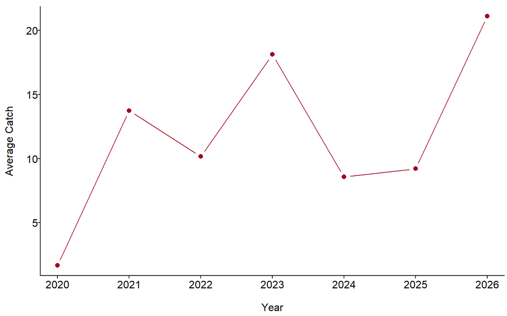

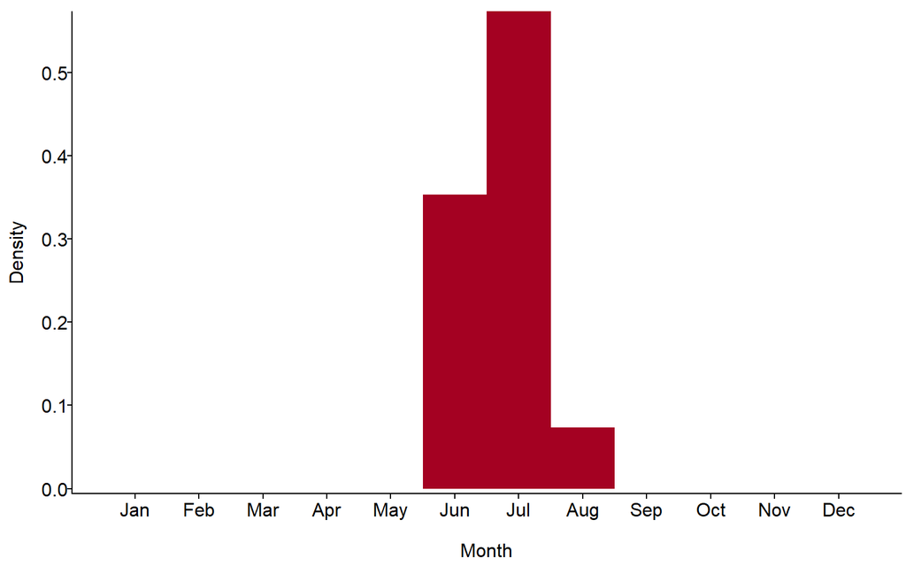

## Common marbled carpet

In total, I have caught 26 individuals of Common marbled carpet, in 15 traps, between 2020 and 2025.

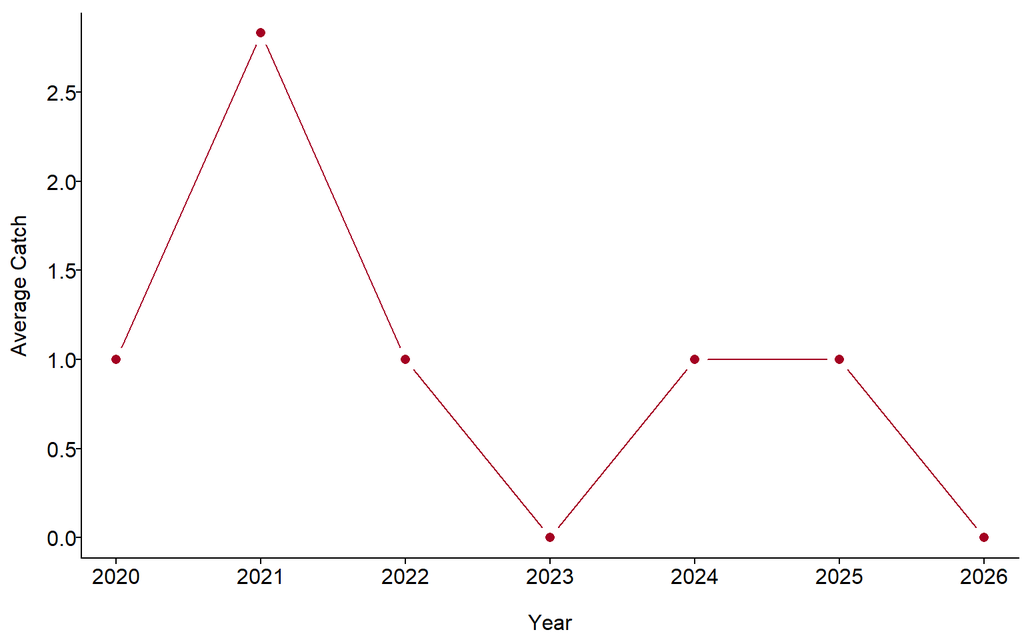

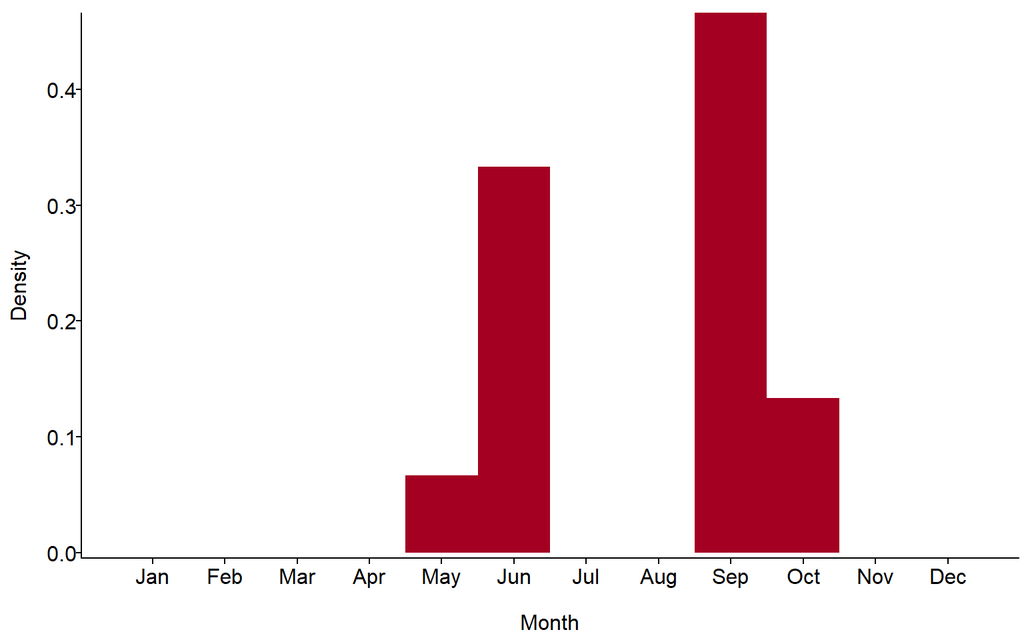

## Common pug

In total, I have caught 43 individuals of Common pug, in 28 traps, between 2021 and 2026.

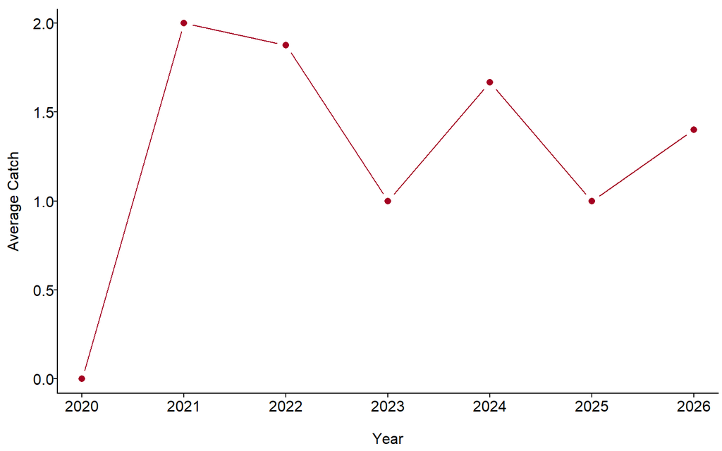

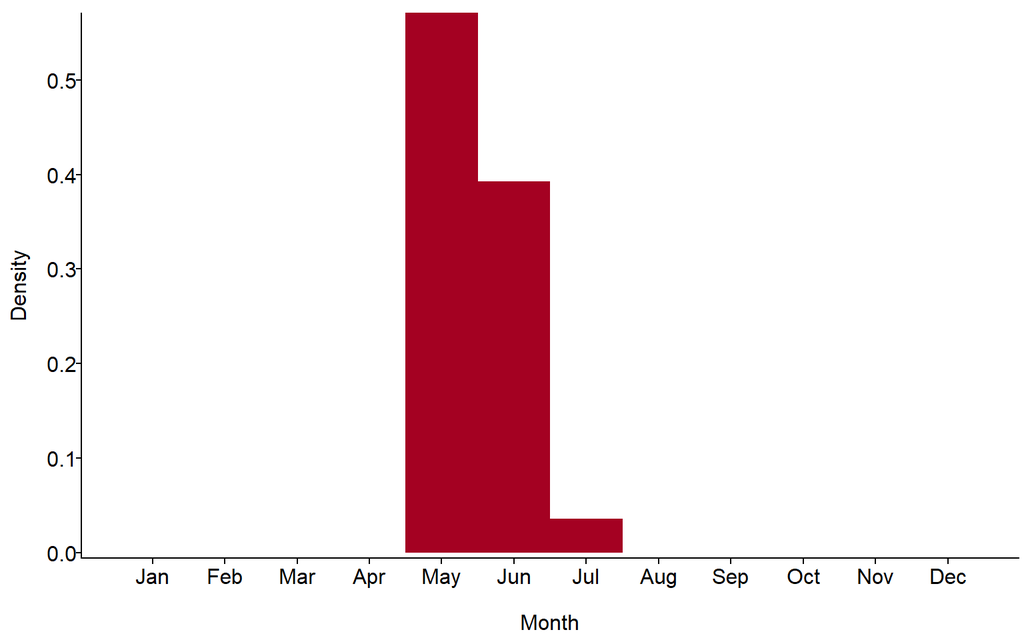

## Common quaker

In total, I have caught 137 individuals of Common quaker, in 46 traps, between 2021 and 2026.

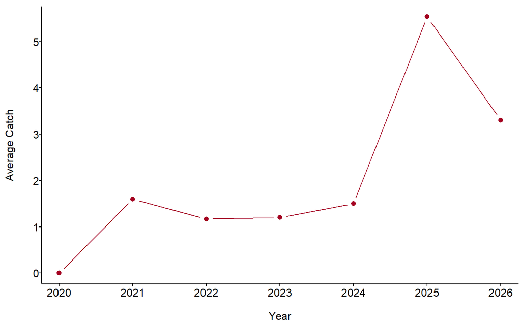

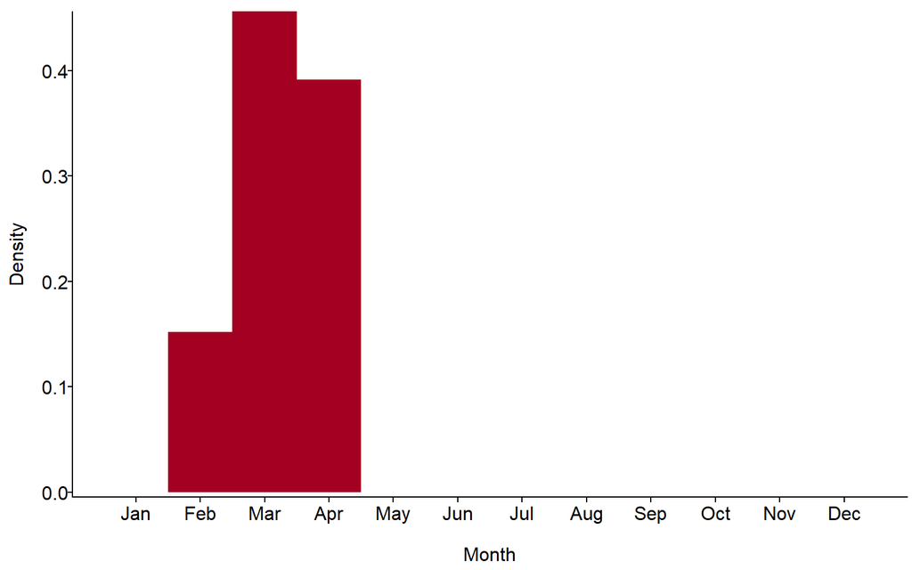

## Common rustic

In total, I have caught 137 individuals of Common rustic, in 51 traps, between 2020 and 2026.

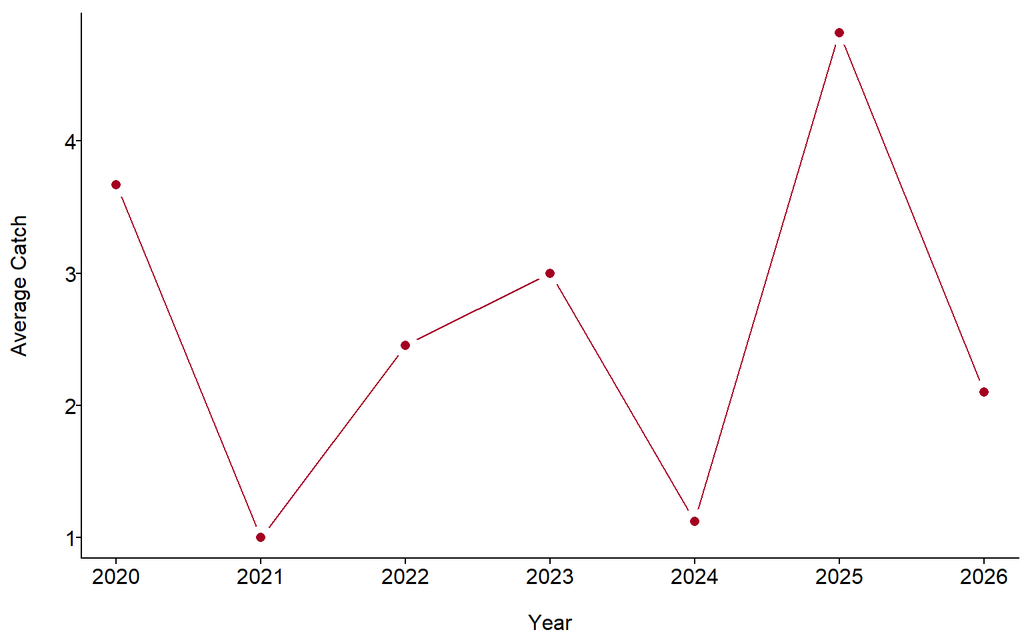

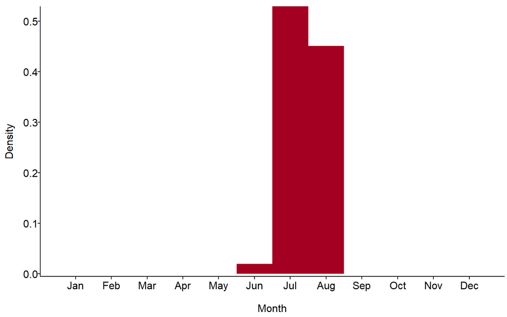

## Common swift

In total, I have caught 16 individuals of Common swift, in 10 traps, between 2021 and 2026.

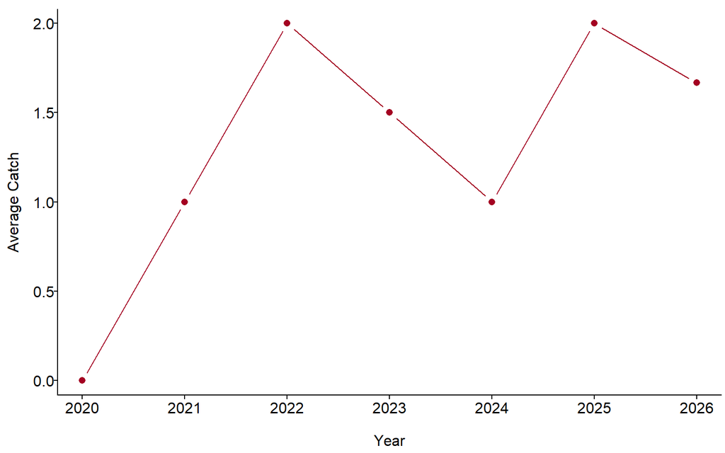

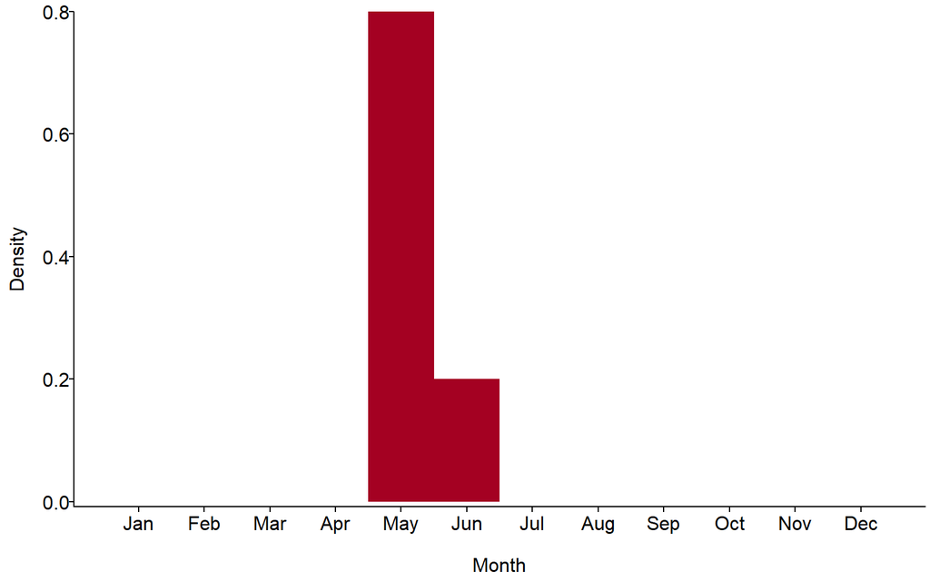